# What features affect the duration of the ride

## by Sadeko Daniel

## Investigation Overview

> In this presentation I will be focusing on the duration of ride in minutes and looking at the features of the ride that can affect the duration of the ride. I will be looking at a feature engineered variable (distance), the day and hour of the ride,the type of user (subscriber or not) and the bike share feature.

## Dataset Overview

> The dataset consists of about 183,000 rides consisting of the necessary features I will be looking at, and other features, some were feature engineered to get a better information and some data were removed due to missing information and incosistencies to make the analysis go smoothly

## Distribution of Duration

The duration of ride is a distributed on values from 1 minutes to about 1400 minutes. The distribution is plotted on a logarithmic scale showing clearly majority of the rides are within a low duration of about 3 to 25 minutes.

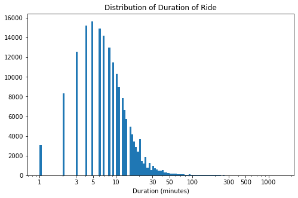

## Distribution of Distance

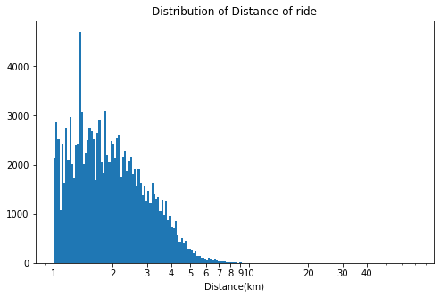

## Hour and Day distribution of rides

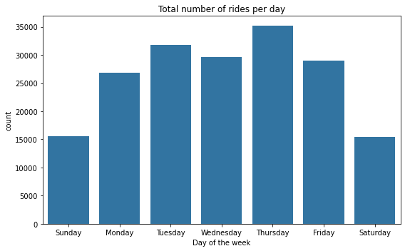

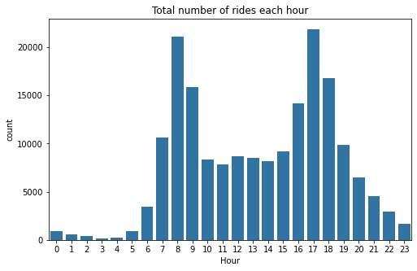

## Duration vs Distance

Plotting the duration on a logarithmic scale and the distance on a logarithmic scale gives a fair relationship showing that most of the duration of ride still occur within short distances of 1 to 5 kilometres. The data is further analyzed to know other characteristics that would have affect the duration of a ride.

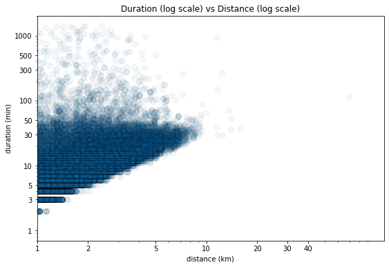

## Duration and Distance of ride by day of the week

Longer rides are seen to occur during the weekends which from the previous chart on the distribution of days of rides, the weekends are days of lesser number of rides, these longer rides still have on average the same distance of ride. These shows that during the weekends, riders generally spend more time riding even for shorter range of distances. Outliers were removed to get a better view of the plot.

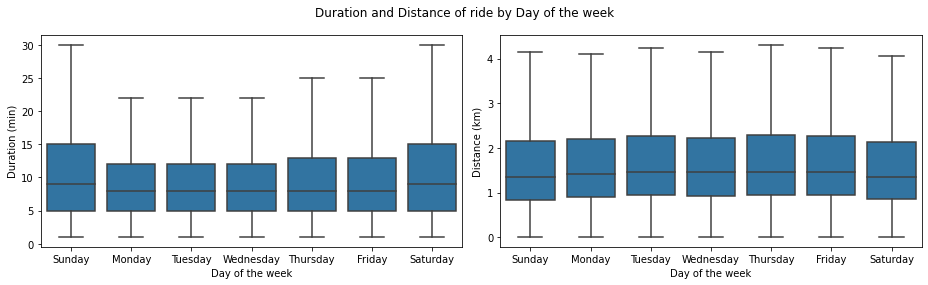

## Duration of ride vs user type and sharing of bikes for trip

In exploring the relationship between non-subscribers with the duration of ride, non-subscribers ride for longer minutes than the subscribers of the GoBike Riders, with an average of about 23 minutes. Subscribers ride on an average of 10 minutes.

Also riders generally don't share their bikes during trips taken but not too a large proportion

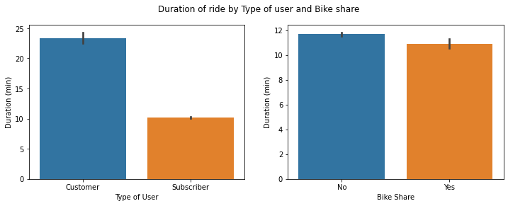

## Relationship between the Duration and the day of the week based on the user_type and bike share

We can see how subscribers and non-subscribers behave during the days of the week with respect ot the time spend on their rides. Non-subscribers tend to have longer duration rides during the weekends (Sundays and Saturdays) and subscribers have longer duration rides during the weekdays.

Looking at it from the sharing of bikes during trip, it can be seen that on those same weekends, riders share their rides during their trip more and during the weekdays, we see more of riders not sharing their bikes for the trips they take.

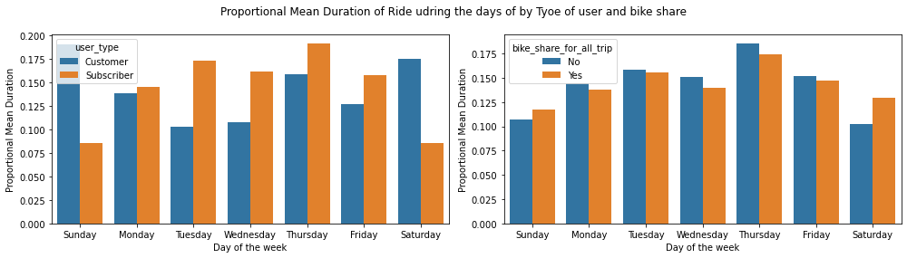